# DS 520Q Team 17: Ames House Project

Team 17: Arya Pedneka, Dawit Yang, Iris Zhang, Shreya Nair, Yanqing Xu

2025-09-28

```r
# Load necessary libraries
library(ggplot2)     # For data visualization
library(car)         # For Q-Q plots
library(ggcorrplot)  # For heatmaps
library(dplyr)       # For data manipulation (equivalent to pandas)
library(tidyr)       # For data tidying
library(scales)      # For formatting numerical outputs
library(readr)       # For reading CSV files

# Suppress warnings
options(warn = -1)

# Libraries for statistical analysis
library(MASS)     # Includes functions for normal distribution fitting
library(stats)    # Base statistics package
library(ggpubr)   # For adding statistical annotations to plots
library(Metrics)  # For RMSLE calculation

# Set global float format to 3 decimal points
options(digits = 3)
```

## Introduction

```r
# Import train and test datasets
train <- read.csv("train.csv")
test <- read.csv("test.csv")

# Extract the target variable 'SalePrice' from the test dataset
y_test <-test$SalePrice

# Verify the structure of the datasets
str(train)
```

```
## 'data.frame':    1460 obs. of  81 variables:
##  $ Id           : int  1 2 3 4 5 6 7 8 9 10 ...
##  $ MSSubClass   : int  60 20 60 70 60 50 20 60 50 190 ...
##  $ MSZoning     : chr  "RL" "RL" "RL" "RL" ...
##  $ LotFrontage  : int  65 80 68 60 84 85 75 NA 51 50 ...
##  $ LotArea      : int  8450 9600 11250 9550 14260 14115 10084 10382 6120 7420 ...
##  $ Street       : chr  "Pave" "Pave" "Pave" "Pave" ...
##  $ Alley        : chr  NA NA NA NA ...
##  $ LotShape     : chr  "Reg" "Reg" "IR1" "IR1" ...
##  $ LandContour  : chr  "Lvl" "Lvl" "Lvl" "Lvl" ...
##  $ Utilities    : chr  "AllPub" "AllPub" "AllPub" "AllPub" ...
##  $ LotConfig    : chr  "Inside" "FR2" "Inside" "Corner" ...
##  $ LandSlope    : chr  "Gtl" "Gtl" "Gtl" "Gtl" ...
##  $ Neighborhood : chr  "CollgCr" "Veenker" "CollgCr" "Crawfor" ...
##  $ Condition1   : chr  "Norm" "Feedr" "Norm" "Norm" ...
```

[output cut: 67 more lines]

```r
str(test)
```

```
## 'data.frame':    1447 obs. of  81 variables:
##  $ Id           : int  1461 1462 1463 1464 1465 1466 1467 1468 1469 1470 ...
##  $ MSSubClass   : int  20 20 60 60 120 60 20 60 20 20 ...
##  $ MSZoning     : chr  "RH" "RL" "RL" "RL" ...
##  $ LotFrontage  : int  80 81 74 78 43 75 NA 63 85 70 ...
##  $ LotArea      : int  11622 14267 13830 9978 5005 10000 7980 8402 10176 8400 ...
##  $ Street       : chr  "Pave" "Pave" "Pave" "Pave" ...
##  $ Alley        : chr  NA NA NA NA ...
##  $ LotShape     : chr  "Reg" "IR1" "IR1" "IR1" ...
##  $ LandContour  : chr  "Lvl" "Lvl" "Lvl" "Lvl" ...
##  $ Utilities    : chr  "AllPub" "AllPub" "AllPub" "AllPub" ...
##  $ LotConfig    : chr  "Inside" "Corner" "Inside" "Inside" ...
##  $ LandSlope    : chr  "Gtl" "Gtl" "Gtl" "Gtl" ...
##  $ Neighborhood : chr  "NAmes" "NAmes" "Gilbert" "Gilbert" ...
##  $ Condition1   : chr  "Feedr" "Norm" "Norm" "Norm" ...
```

[output cut: 67 more lines]

Check the first 5 rows of the train data

```r
head(train, 5)
```

```
##   Id MSSubClass MSZoning LotFrontage LotArea Street Alley LotShape LandContour
## 1  1         60       RL          65    8450   Pave  <NA>      Reg         Lvl
## 2  2         20       RL          80    9600   Pave  <NA>      Reg         Lvl
## 3  3         60       RL          68   11250   Pave  <NA>      IR1         Lvl
## 4  4         70       RL          60    9550   Pave  <NA>      IR1         Lvl
## 5  5         60       RL          84   14260   Pave  <NA>      IR1         Lvl
##   Utilities LotConfig LandSlope Neighborhood Condition1 Condition2 BldgType
## 1    AllPub    Inside       Gtl      CollgCr       Norm       Norm     1Fam
## 2    AllPub       FR2       Gtl      Veenker      Feedr       Norm     1Fam
## 3    AllPub    Inside       Gtl      CollgCr       Norm       Norm     1Fam
## 4    AllPub    Corner       Gtl      Crawfor       Norm       Norm     1Fam
## 5    AllPub       FR2       Gtl      NoRidge       Norm       Norm     1Fam
##   HouseStyle OverallQual OverallCond YearBuilt YearRemodAdd RoofStyle RoofMatl
## 1     2Story           7           5      2003         2003     Gable  CompShg
## 2     1Story           6           8      1976         1976     Gable  CompShg
```

[output cut: 57 more lines]

Check the first 5 rows of the test data

```r
head(test, 5)
```

```
##     Id MSSubClass MSZoning LotFrontage LotArea Street Alley LotShape
## 1 1461         20       RH          80   11622   Pave  <NA>      Reg
## 2 1462         20       RL          81   14267   Pave  <NA>      IR1
## 3 1463         60       RL          74   13830   Pave  <NA>      IR1
## 4 1464         60       RL          78    9978   Pave  <NA>      IR1
## 5 1465        120       RL          43    5005   Pave  <NA>      IR1
##   LandContour Utilities LotConfig LandSlope Neighborhood Condition1 Condition2
## 1         Lvl    AllPub    Inside       Gtl        NAmes      Feedr       Norm
## 2         Lvl    AllPub    Corner       Gtl        NAmes       Norm       Norm
## 3         Lvl    AllPub    Inside       Gtl      Gilbert       Norm       Norm
## 4         Lvl    AllPub    Inside       Gtl      Gilbert       Norm       Norm
## 5         HLS    AllPub    Inside       Gtl      StoneBr       Norm       Norm
##   BldgType HouseStyle OverallQual OverallCond YearBuilt YearRemodAdd RoofStyle
## 1     1Fam     1Story           5           6      1961         1961     Gable
## 2     1Fam     1Story           6           6      1958         1958       Hip
```

[output cut: 57 more lines]

```r
# Check the number of samples and features before dropping the 'Id' column
cat("The train data size before dropping Id feature is:", dim(train), "\n")
```

```
## The train data size before dropping Id feature is: 1460 81
```

```r
cat("The test data size before dropping Id feature is:", dim(test), "\n")
```

```
## The test data size before dropping Id feature is: 1447 81
```

```r
# Save the 'Id' column
train_ID <- train$Id
test_ID <- test$Id

# Drop the 'Id' column since it's unnecessary for the prediction process
train <- train[, !(names(train) %in% c("Id"))]
test <- test[, !(names(test) %in% c("Id"))]

# Check the number of samples and features after dropping the 'Id' column
cat("\nThe train data size after dropping Id feature is:", dim(train), "\n")
```

```
##
## The train data size after dropping Id feature is: 1460 80
```

```r
cat("The test data size after dropping Id feature is:", dim(test), "\n")
```

```
## The test data size after dropping Id feature is: 1447 80
```

## Data Processing

### Outliers

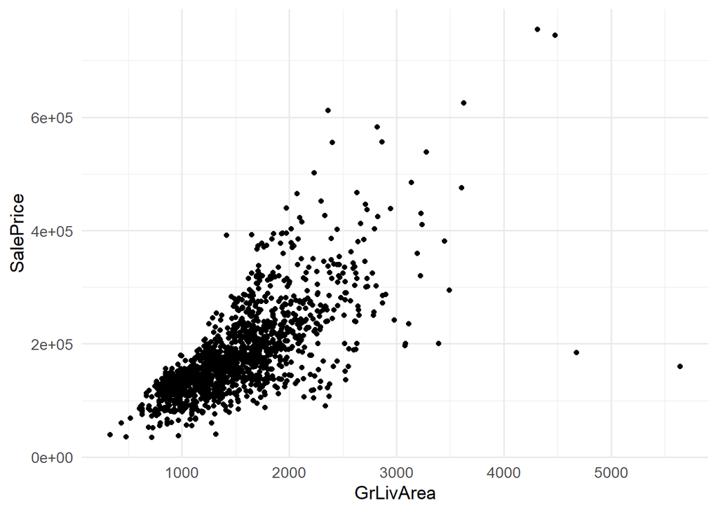

```r
# Create a scatter plot
ggplot(data = train, aes(x = GrLivArea, y = SalePrice)) +
  geom_point() +  # Add scatter points
  labs(x = "GrLivArea", y = "SalePrice") +  # Add axis labels
  theme_minimal(base_size = 13)  # Set font size and minimal theme
```

At the bottom right, we notice two data points with exceptionally large GrLivArea but surprisingly low prices. These points are significant outliers and can be reasonably removed from the dataset.

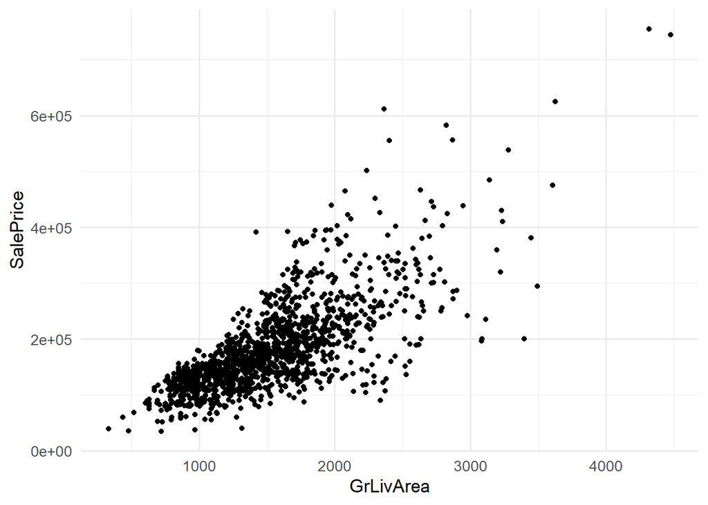

```r
# Deleting outliers
train <- train[!(train$GrLivArea > 4000 & train$SalePrice < 300000), ]

# Check the graphic again
library(ggplot2)
ggplot(data = train, aes(x = GrLivArea, y = SalePrice)) +
  geom_point() +
  labs(x = "GrLivArea", y = "SalePrice") +
  theme_minimal(base_size = 13)
```

### Target Varialble

Our target variable is **SalePrice**.

```r
# Fit the normal distribution to 'SalePrice'
mu <- mean(train$SalePrice)  # Mean
sigma <- sd(train$SalePrice) # Standard deviation
cat("\nmu =", round(mu, 2), "and sigma =", round(sigma, 2), "\n")
```

```
##
## mu = 180933 and sigma = 79495
```

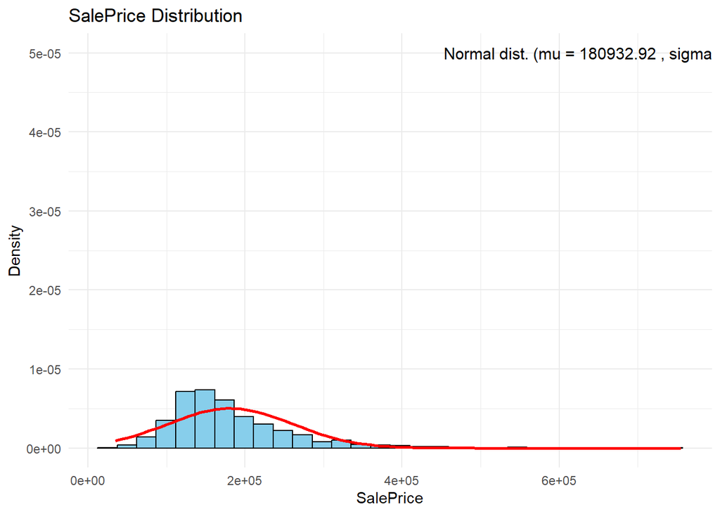

```r
# Plot the distribution with the fitted normal curve
ggplot(train, aes(x = SalePrice)) +
  geom_histogram(aes(y = ..density..), bins = 30, color = "black", fill = "skyblue") +
  stat_function(fun = dnorm, args = list(mean = mu, sd = sigma),
                color = "red", linewidth = 1) +
  labs(title = "SalePrice Distribution", y = "Density", x = "SalePrice") +
  theme_minimal() +
  annotate("text", x = max(train$SalePrice) * 0.6, y = 0.00005,
           label = paste("Normal dist. (mu =", round(mu, 2), ", sigma =", round(sigma, 2), ")"),
           hjust = 0, size = 4)
```

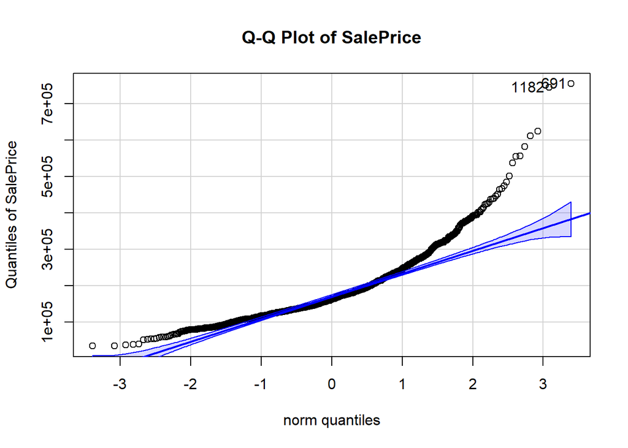

```
## [1]  691 1182
```

```r
# Q-Q plot
qqPlot(train$SalePrice, main = "Q-Q Plot of SalePrice", ylab = "Quantiles of SalePrice")
```

The target variable exhibits right skewness. Since (linear) models perform better with normally distributed data, we need to transform this variable to approximate a normal distribution.

**Log-transformation of the target variable**

```r
#Duplicate one data set just for now
df <- train

# Apply the log1p transformation (log(1 + x)) to 'SalePrice'
df$SalePrice <- log1p(df$SalePrice)

# Check the new distribution
library(ggplot2)
mu <- mean(df$SalePrice)  # Calculate the mean
sigma <- sd(df$SalePrice) # Calculate the standard deviation
cat("\nmu =", round(mu, 2), "and sigma =", round(sigma, 2), "\n")
```

```
##
## mu = 12 and sigma = 0.4
```

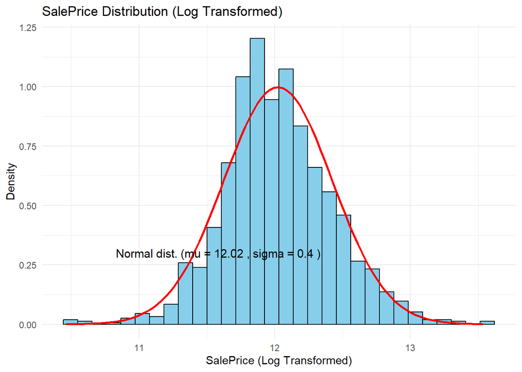

```r
# Plot the distribution with the fitted normal curve
ggplot(df, aes(x = SalePrice)) +
  geom_histogram(aes(y = ..density..), bins = 30, color = "black", fill = "skyblue") +
  stat_function(fun = dnorm, args = list(mean = mu, sd = sigma),
                color = "red", linewidth = 1) +  # Use `linewidth` instead of `size`
  labs(title = "SalePrice Distribution (Log Transformed)",
       y = "Density", x = "SalePrice (Log Transformed)") +
  theme_minimal() +
  annotate("text", x = max(df$SalePrice) * 0.8, y = 0.3,
           label = paste("Normal dist. (mu =", round(mu, 2), ", sigma =", round(sigma, 2), ")"),
           hjust = 0, size = 4)
```

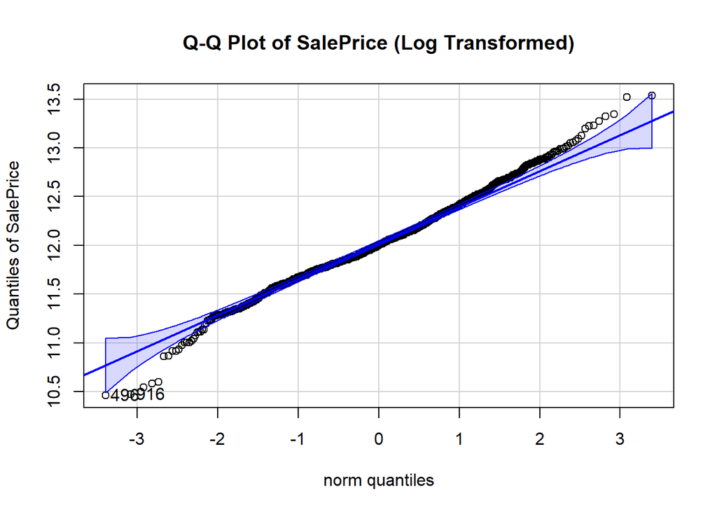

```
## [1] 496 916
```

```r
# Generate the Q-Q plot
library(car)  # For Q-Q plots
qqPlot(df$SalePrice, main = "Q-Q Plot of SalePrice (Log Transformed)",
       ylab = "Quantiles of SalePrice")
```

The skewness has been addressed, and the data now appears to follow a more normal distribution.

### Features engineering

Let’s start by merging the train and test datasets into a single dataframe.

```r
# Record the number of rows in the train and test datasets
ntrain <- nrow(train)
ntest <- nrow(test)

# Extract the target variable 'SalePrice' from the train dataset
y_train <- train$SalePrice

# Combine train and test datasets
all_data <- rbind(train, test)

# Remove the 'SalePrice' column from the combined dataset
all_data <- all_data[, !names(all_data) %in% c("SalePrice")]

# Display the size of the combined dataset
cat("all_data size is:", dim(all_data), "\n")
```

```
## all_data size is: 2905 79
```

**Missing data**

```r
# Calculate the percentage of missing values for each column
all_data_na <- colSums(is.na(all_data)) / nrow(all_data) * 100

# Filter columns with missing values and sort them in descending order
all_data_na <- sort(all_data_na[all_data_na > 0], decreasing = TRUE)

# Create a dataframe to display the missing ratio
missing_data <- data.frame(Missing_Ratio = all_data_na)

# Display the first 20 rows of the missing data
head(missing_data, 20)
```

```
##              Missing_Ratio
## PoolQC             99.6902
## MiscFeature        96.3855
## Alley              93.2186
## Fence              80.4819
## FireplaceQu        48.6059
## LotFrontage        16.6954
## GarageYrBlt         5.4045
## GarageFinish        5.4045
## GarageQual          5.4045
## GarageCond          5.4045
## GarageType          5.3701
## BsmtExposure        2.6850
## BsmtQual            2.6506
## BsmtFinType2        2.6162
## BsmtCond            2.5818
## BsmtFinType1        2.5818
## MasVnrType          0.8262
## MasVnrArea          0.7917
## Utilities           0.0344
## Electrical          0.0344
```

**Data Correlation**

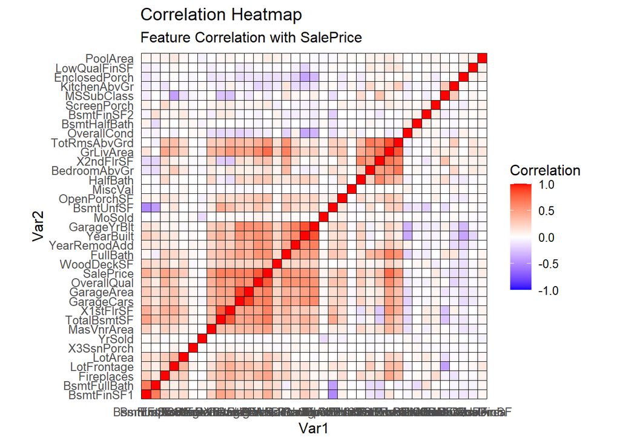

```r
# Select only numeric columns from the train dataset
numeric_train <- train[, sapply(train, is.numeric)]

# Compute the correlation matrix
corrmat <- cor(numeric_train, use = "pairwise.complete.obs")

# Plot the heatmap
ggcorrplot(corrmat,
           hc.order = TRUE,   # Hierarchical clustering order
           type = "full",     # Show full matrix
           lab = FALSE,       # Remove correlation coefficients from the heatmap
           colors = c("blue", "white", "red"), # Color gradient
           legend.title = "Correlation",
           outline.color = "black") +
  theme_minimal(base_size = 12) +
  labs(title = "Correlation Heatmap",
       subtitle = "Feature Correlation with SalePrice")
```

To identify key predictors for ‘SalePrice’, the correlation of numerical variables with the target variable was analyzed. Variables with the highest correlations including ‘OverallQual’,‘GrLivArea’,‘GarageCars’ and ‘TotalBsmtSF’. These early indicators highlighted the importance of size and quality-related variables in predicting home prices.

This findings suggested a combination of linear and nonlinear modeling approaches. Linear models could effectively capture the relationships between SalePrice and key predictors such as OverallQual and GrLivArea, especially after applying a log transformation to the target variable. Nonlinear models, such as decision trees and boosting algorithms, could handle complex interactions and nonlinear relationships among predictors.

**Imputting missing values**

We fill the missing values by addressing each feature sequentially.

**PoolQC**: According to the data description, NA indicates “No Pool.” This is logical considering the high percentage of missing values (over 99%) and the fact that most houses typically do not have a pool.

```r
# Replace NA values in the 'PoolQC' column with "None"
all_data$PoolQC[is.na(all_data$PoolQC)] <- "None"
```

**MiscFeature**: As per the data description, NA signifies “no miscellaneous feature.”

```r
# Replace NA values in the 'MiscFeature' column with "None"
all_data$MiscFeature[is.na(all_data$MiscFeature)] <- "None"
```

**Alley**: According to the data description, NA indicates “no alley access.”

```r
# Replace NA values in the 'Alley' column with "None"
all_data$Alley[is.na(all_data$Alley)] <- "None"
```

**Fence**: As described in the data documentation, NA represents “no fence.”

```r
# Replace NA values in the 'Fence' column with "None"
all_data$Fence[is.na(all_data$Fence)] <- "None"
```

**FireplaceQu**: According to the data description, NA denotes “no fireplace.”

```r
# Replace NA values in the 'FireplaceQu' column with "None"
all_data$FireplaceQu[is.na(all_data$FireplaceQu)] <- "None"
```

**LotFrontage**: Since the area of each street connected to a house is likely similar to that of other houses in the same neighborhood, missing values can be filled using the median LotFrontage for the corresponding neighborhood.

```r
# Group by 'Neighborhood' and fill missing 'LotFrontage' with the median for each neighborhood
all_data <- all_data %>%
  group_by(Neighborhood) %>%
  mutate(LotFrontage = ifelse(is.na(LotFrontage), median(LotFrontage, na.rm = TRUE), LotFrontage)) %>%
  ungroup()
```

**GarageType, GarageFinish, GarageQual, and GarageCond**: Missing data is replaced with “None”.

```r
# Replace NA values in the specified columns with "None"
columns_to_replace <- c("GarageType", "GarageFinish", "GarageQual", "GarageCond")

for (col in columns_to_replace) {
  all_data[[col]][is.na(all_data[[col]])] <- "None"
}
```

**GarageYrBlt, GarageArea, and GarageCars**: Missing data is replaced with 0, as the absence of a garage implies no cars or related features.

```r
# Replace NA values in the specified columns with 0
columns_to_replace <- c("GarageYrBlt", "GarageArea", "GarageCars")

for (col in columns_to_replace) {
  all_data[[col]][is.na(all_data[[col]])] <- 0
}
```

**BsmtFinSF1, BsmtFinSF2, BsmtUnfSF, TotalBsmtSF, BsmtFullBath, and BsmtHalfBath**: Missing values are assumed to be zero, indicating the absence of a basement.

```r
# Replace NA values in the specified columns with 0
columns_to_replace <- c('BsmtFinSF1', 'BsmtFinSF2', 'BsmtUnfSF', 'TotalBsmtSF', 'BsmtFullBath', 'BsmtHalfBath')

for (col in columns_to_replace) {
  all_data[[col]][is.na(all_data[[col]])] <- 0
}
```

**BsmtQual, BsmtCond, BsmtExposure, BsmtFinType1, and BsmtFinType2**: For these categorical basement-related features, NaN indicates the absence of a basement.

```r
# Replace NA values in the specified columns with "None"
columns_to_replace <- c('BsmtQual', 'BsmtCond', 'BsmtExposure', 'BsmtFinType1', 'BsmtFinType2')

for (col in columns_to_replace) {
  all_data[[col]][is.na(all_data[[col]])] <- "None"
}
```

**MasVnrArea and MasVnrType**: NA likely indicates the absence of a masonry veneer in these houses. We can fill 0 for the area and “None” for the type.

```r
# Replace NA values in 'MasVnrType' with "None" and in 'MasVnrArea' with 0
all_data$MasVnrType[is.na(all_data$MasVnrType)] <- "None"
all_data$MasVnrArea[is.na(all_data$MasVnrArea)] <- 0
```

**MSZoning (The general zoning classification)**: Since ‘RL’ is the most common value, we can replace missing values with ‘RL’.

```r
# Replace NA values in 'MSZoning' with the most common value (mode)
all_data$MSZoning[is.na(all_data$MSZoning)] <- names(sort(table(all_data$MSZoning), decreasing = TRUE))[1]
```

```r
# Remove the 'Utilities' column from the dataset
all_data <- all_data[, !names(all_data) %in% c("Utilities")]
```

**Functional**: According to the data description, NA indicates a typical function.

```r
# Replace NA values in 'Functional' with "Typ"
all_data$Functional[is.na(all_data$Functional)] <- "Typ"
```

**Electrical**: This feature has one missing value. Since the majority of records are ‘SBrkr’, we can replace the missing value with ‘SBrkr’.

```r
# Replace NA values in 'Electrical' with the most common value (mode)
all_data$Electrical[is.na(all_data$Electrical)] <- names(sort(table(all_data$Electrical), decreasing = TRUE))[1]
```

**KitchenQual**: There is only one missing value, and similar to the Electrical feature, we will replace the missing value with ‘TA’, as it is the most frequent value.

```r
# Replace NA values in 'KitchenQual' with the most common value (mode)
all_data$KitchenQual[is.na(all_data$KitchenQual)] <- names(sort(table(all_data$KitchenQual), decreasing = TRUE))[1]
```

**Exterior1st and Exterior2nd**: Both Exterior1st and Exterior2nd have only one missing value. We will replace these missing values with the most common string for each feature.

```r
# Replace NA values in 'Exterior1st' and 'Exterior2nd' with the most common value (mode)
all_data$Exterior1st[is.na(all_data$Exterior1st)] <- names(sort(table(all_data$Exterior1st), decreasing = TRUE))[1]
all_data$Exterior2nd[is.na(all_data$Exterior2nd)] <- names(sort(table(all_data$Exterior2nd), decreasing = TRUE))[1]
```

**SaleType**: We will replace the missing value with the most frequent value, which is “WD”.

```r
# Replace NA values in 'SaleType' with the most common value (mode)
all_data$SaleType[is.na(all_data$SaleType)] <- names(sort(table(all_data$SaleType), decreasing = TRUE))[1]
```

**MSSubClass**: NA likely indicates no building class. We can replace the missing values with “None”.

```r
# Replace NA values in 'MSSubClass' with "None"
all_data$MSSubClass[is.na(all_data$MSSubClass)] <- "None"
```

**Checking if there are any missing value**

```r
# Calculate the percentage of missing values for each column
all_data_na <- colSums(is.na(all_data)) / nrow(all_data) * 100

# Filter columns with missing values and sort them in descending order
all_data_na <- sort(all_data_na[all_data_na > 0], decreasing = TRUE)

# Create a dataframe to display the missing ratio
missing_data <- data.frame(Missing_Ratio = all_data_na)

# Display the top rows of the missing data
head(missing_data)
```

```
## [1] Missing_Ratio
## <0 rows> (or 0-length row.names)
```

**Transforming certain numerical variables that are actually categorical.**

```r
# MSSubClass = The building class
all_data$MSSubClass <- as.character(all_data$MSSubClass)

# Changing OverallCond into a categorical variable
all_data$OverallCond <- as.factor(all_data$OverallCond)

# Year and month sold are transformed into categorical features
all_data$YrSold <- as.factor(all_data$YrSold)
all_data$MoSold <- as.factor(all_data$MoSold)
```

**Label encoding certain categorical variables that may have meaningful order or hierarchy.**

```r
# List of columns to apply label encoding
cols <- c('FireplaceQu', 'BsmtQual', 'BsmtCond', 'GarageQual', 'GarageCond',
          'ExterQual', 'ExterCond', 'HeatingQC', 'PoolQC', 'KitchenQual', 'BsmtFinType1',
          'BsmtFinType2', 'Functional', 'Fence', 'BsmtExposure', 'GarageFinish', 'LandSlope',
          'LotShape', 'PavedDrive', 'Street', 'Alley', 'CentralAir', 'MSSubClass', 'OverallCond',
          'YrSold', 'MoSold')

# Apply label encoding to categorical columns
for (col in cols) {
  all_data[[col]] <- as.integer(factor(all_data[[col]]))
}

# Display the shape of the dataset
cat("Shape of all_data:", dim(all_data), "\n")
```

```
## Shape of all_data: 2905 78
```

**Adding another crucial feature**

Since area-related features play a significant role in determining house prices, we are adding a new feature that represents the total area, which is the sum of the basement area, first floor area, and second floor area for each house.

```r
# Adding total square footage feature
all_data$TotalSF <- all_data$TotalBsmtSF + all_data$`X1stFlrSF` + all_data$`X2ndFlrSF`
```

**Skewed features**

```r
# Load necessary library
library(e1071)

# Select only numeric columns
numeric_feats <- sapply(all_data, is.numeric)

# Calculate skewness for each numeric feature
skewed_feats <- sapply(all_data[, numeric_feats], function(x) skewness(x, na.rm = TRUE))

# Sort the skewness values in descending order
skewed_feats <- sort(skewed_feats, decreasing = TRUE)

# Create a data frame to display skewness values
skewness <- data.frame(Skew = skewed_feats)

# Display the top 10 skewed features
head(skewness, 10)
```

```
##                Skew
## MiscVal       21.88
## PoolArea      17.64
## LotArea       13.35
## LowQualFinSF  12.07
## X3SsnPorch    11.34
## LandSlope      4.98
## KitchenAbvGr   4.29
## BsmtFinSF2     4.14
## EnclosedPorch  4.02
## ScreenPorch    3.93
```

**Box-Cox Transformation for (Highly) Skewed Features:** We use the boxcox function from the MASS package to perform the Box-Cox transformation. For data where x + 1 is required, we apply the boxcox function with the parameter lambda to perform the transformation.

```r
# Calculate skewness for numeric features (assumes skewness variable is already calculated)
skewness <- skewness[abs(skewness) > 0.75]
cat("There are", length(skewness), "skewed numerical features to Box-Cox transform\n")
```

```
## There are 36 skewed numerical features to Box-Cox transform
```

```r
# Specify the skewed features and lambda
skewed_features <- names(skewness)
lam <- 0.15

# Apply Box-Cox transformation to skewed features
for (feat in skewed_features) {
  all_data[[feat]] <- boxcox(all_data[[feat]] + 1, lambda = lam)$y
}
```

**Creating dummy variables for categorical features**

```r
# Create dummy variables for categorical features
all_data <- model.matrix(~ . - 1, data = all_data)

# Check the dimensions of the transformed dataset
cat("Shape of all_data:", dim(all_data), "\n")
```

```
## Shape of all_data: 2905 201
```

**Creating the new training and testing datasets**

```r
# Create the new train and test sets
train <- all_data[1:ntrain, ]
test <- all_data[(ntrain + 1):nrow(all_data), ]
```

```r
class(train)
```

```
## [1] "matrix" "array"
```

```r
class(y_train)
```

```
## [1] "integer"
```

```r
class(test)
```

```
## [1] "matrix" "array"
```

## Modelling

After data cleaning and feature engineering, we found that the data has a certain level of complexity. For example, some features exhibit strong correlations, and the feature types are diverse, including numerical, categorical, and ordinal data.

Therefore, we need to focus on more robust models.

To combine linear and non-linear models, we selected four models with the aim of identifying the best one and leveraging their strengths for optimal prediction results. First, we chose LASSO because it helps reduce the impact of irrelevant features. Next, we chose Random Forest, as it is a powerful non-linear model capable of handling complex relationships between features. Then, we selected GBR, which excels at capturing intricate relationships between features. Finally, we chose XGBoost because it is well-suited for handling high-dimensional data and has outstanding model performance, further improving prediction accuracy with each optimization.

### Librairies

```r
# Load necessary libraries
library(glmnet)         # ElasticNet and Lasso
library(Metrics)        # For Mean Squared Error (MSE)
library(randomForest)   # For RandomForestRegressor
library(gbm)            # For GradientBoostingRegressor
library(kernlab)        # For KernelRidge
library(caret)          # For model training and cross-validation
library(xgboost)        # For XGBoost
library(lightgbm)       # For LightGBM
library(Metrics)        # For calculating MSE
library(robustbase)     # For RobustScaler
```

### Base Models

#### Lasso Regression

```r
# Convert train and test data matrices to data frames
train_df <- as.data.frame(train)   # Convert train to data frame
test_df <- as.data.frame(test)     # Convert test to data frame

# Ensure y_train is a vector and not a matrix/array
y_train_df <- as.vector(y_train)  # Convert y_train to a vector

# Perform scaling on train and test data consistently
train_scaled_df <- scale(train_df)  # Scaling the training data
test_scaled_df <- scale(test_df, center = attr(train_scaled_df, "scaled:center"), scale = attr(train_scaled_df, "scaled:scale"))  # Use the same scaling as the training set

# Fit the Lasso regression model using glmnet
lasso_model <- glmnet(train_scaled_df, y_train_df, alpha = 1, lambda = 0.0005)

# View the model results
print(lasso_model)
```

```
##
## Call:  glmnet(x = train_scaled_df, y = y_train_df, alpha = 1, lambda = 5e-04)
##
##    Df %Dev Lambda
## 1 201 92.7  5e-04
```

```r
# Perform cross-validation with glmnet to select the optimal lambda
cv_lasso_model <- cv.glmnet(train_scaled_df, y_train_df, alpha = 1)

# View the results from cross-validation
print(cv_lasso_model)
```

```
##
## Call:  cv.glmnet(x = train_scaled_df, y = y_train_df, alpha = 1)
##
## Measure: Mean-Squared Error
##
##     Lambda Index  Measure       SE Nonzero
## min    693    50 7.04e+08 94911072      85
## 1se   2551    36 7.93e+08 95397595      37
```

```r
# Make predictions on the test data
predictions_lasso <- predict(cv_lasso_model, newx = test_scaled_df, s = "lambda.min")
```

#### Random Forest

```r
# Clean column names by removing special characters or spaces
colnames(train) <- gsub("[^[:alnum:]_]", "", colnames(train))
colnames(test) <- gsub("[^[:alnum:]_]", "", colnames(test))
```

```r
# Convert train and test data matrices to data frames
train_df <- as.data.frame(train)  # Convert train to data frame
test_df <- as.data.frame(test)    # Convert test to data frame

# Ensure y_train is a vector and not a matrix/array
y_train_df <- as.vector(y_train)  # Convert y_train to a vector

# Fit the Random Forest regression model
rf_model <- randomForest(x = train_df, y = y_train_df, importance = TRUE)

# Print the model summary
print(rf_model)
```

```
##
## Call:
##  randomForest(x = train_df, y = y_train_df, importance = TRUE)
##                Type of random forest: regression
##                      Number of trees: 500
## No. of variables tried at each split: 67
##
##           Mean of squared residuals: 6.16e+08
##                     % Var explained: 90.2
```

```r
# Check the importance of each feature
importance(rf_model)
```

```
##                      %IncMSE IncNodePurity
## MSSubClass            9.9816      2.11e+10
## MSZoningCall          3.8379      1.73e+09
## MSZoningFV            3.0276      1.32e+09
## MSZoningRH            1.7008      1.99e+08
## MSZoningRL            7.9694      8.03e+09
## MSZoningRM           11.0660      1.17e+10
## LotFrontage           7.0149      5.49e+10
## LotArea              11.1963      1.15e+11
## Street                0.7742      4.16e+08
## Alley                 1.4802      1.51e+09
## LotShape              4.3930      8.04e+09
## LandContourHLS        0.4904      5.20e+09
## LandContourLow        0.9616      3.00e+09
## LandContourLvl        1.6549      5.82e+09
## LotConfigCulDSac      3.4161      3.19e+09
## LotConfigFR2          0.8645      6.19e+08
## LotConfigFR3          1.0010      2.66e+08
## LotConfigInside      -0.6874      4.81e+09
## LandSlope             3.3415      8.22e+09
## NeighborhoodBlueste   0.0000      1.11e+07
## NeighborhoodBrDale    1.4427      4.39e+07
## NeighborhoodBrkSide   1.2363      7.34e+08
## NeighborhoodClearCr   1.3694      1.88e+09
## NeighborhoodCollgCr   3.7496      2.84e+09
## NeighborhoodCrawfor   8.3310      7.54e+09
## NeighborhoodEdwards   3.3919      2.02e+09
## NeighborhoodGilbert   3.8922      9.44e+08
## NeighborhoodIDOTRR   -0.4289      7.01e+08
## NeighborhoodMeadowV   2.9869      2.43e+08
## NeighborhoodMitchel   1.2579      1.21e+09
## NeighborhoodNAmes     3.5179      2.53e+09
## NeighborhoodNoRidge  -0.2646      4.22e+09
## NeighborhoodNPkVill   2.9019      5.49e+07
## NeighborhoodNridgHt   2.1676      3.21e+09
## NeighborhoodNWAmes    1.6400      1.22e+09
## NeighborhoodOldTown   6.0870      3.63e+09
## NeighborhoodSawyer    1.0372      8.77e+08
## NeighborhoodSawyerW   0.6537      8.03e+08
## NeighborhoodSomerst   1.2905      2.77e+09
```

[output cut: 147 more lines]

```
## YrSold               -1.0211      1.31e+10
## SaleTypeCon           0.0000      8.45e+07
## SaleTypeConLD         1.0010      1.01e+08
## SaleTypeConLI         0.9222      2.45e+08
## SaleTypeConLw         0.0000      4.74e+07
## SaleTypeCWD           0.0000      3.32e+08
## SaleTypeNew           2.7633      6.97e+09
## SaleTypeOth           0.0000      6.11e+07
## SaleTypeWD            1.4289      5.28e+09
## SaleConditionAdjLand  0.0000      3.37e+07
## SaleConditionAlloca  -0.7513      7.61e+08
## SaleConditionFamily  -0.7363      3.09e+09
## SaleConditionNormal   1.6923      6.03e+09
## SaleConditionPartial  3.4558      5.01e+09
## TotalSF              35.4359      2.61e+12
```

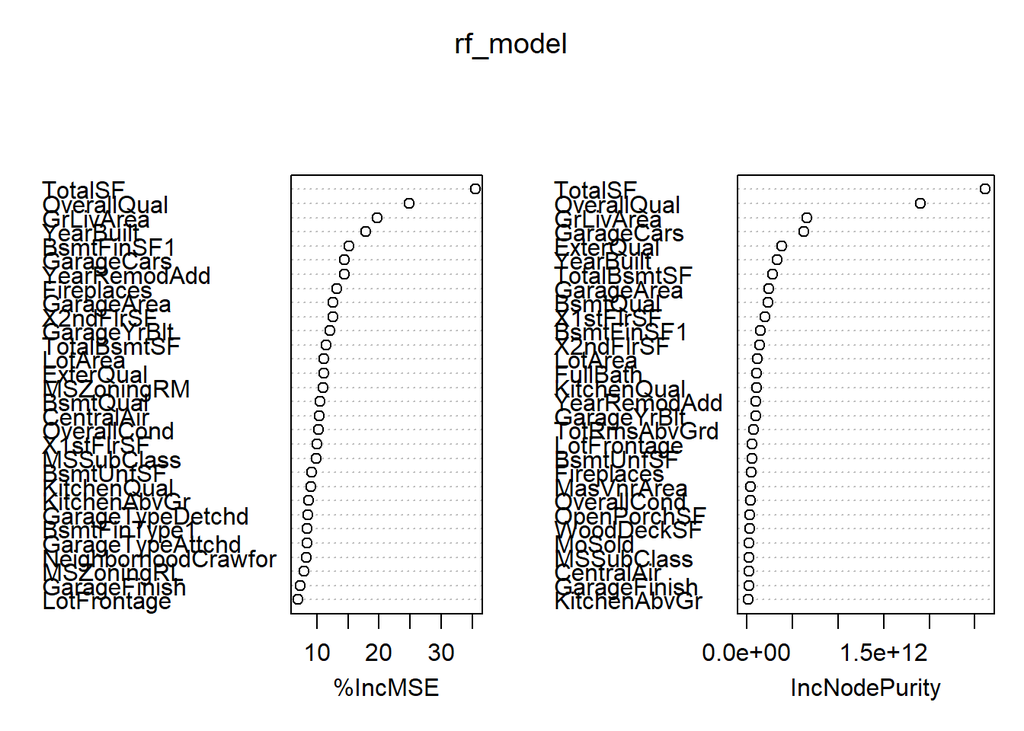

```r
# Plot the feature importance
varImpPlot(rf_model)
```

```r
# Make predictions on the test dataset
predictions_rf <- predict(rf_model, newdata = test_df)
```

#### Gradient Boosting Regression

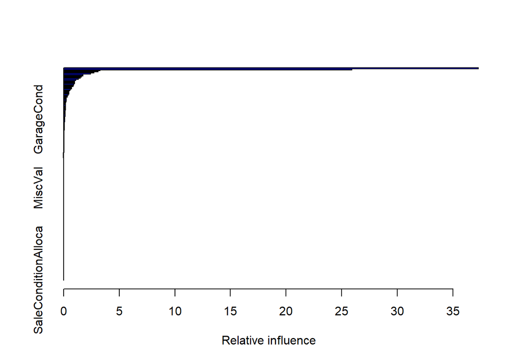

```
##                                       var  rel.inf
## TotalSF                           TotalSF 3.73e+01
## OverallQual                   OverallQual 2.59e+01
## BsmtFinSF1                     BsmtFinSF1 3.26e+00
## YearBuilt                       YearBuilt 3.09e+00
## GrLivArea                       GrLivArea 2.73e+00
## LotArea                           LotArea 2.44e+00
## TotalBsmtSF                   TotalBsmtSF 1.75e+00
## BsmtQual                         BsmtQual 1.73e+00
## GarageCars                     GarageCars 1.59e+00
## GarageArea                     GarageArea 1.50e+00
## YearRemodAdd                 YearRemodAdd 1.33e+00
## KitchenQual                   KitchenQual 1.10e+00
## BsmtUnfSF                       BsmtUnfSF 1.01e+00
## X1stFlrSF                       X1stFlrSF 1.00e+00
## LotFrontage                   LotFrontage 9.82e-01
## OverallCond                   OverallCond 9.38e-01
## X2ndFlrSF                       X2ndFlrSF 8.77e-01
## GarageYrBlt                   GarageYrBlt 8.59e-01
## MasVnrArea                     MasVnrArea 7.27e-01
## Fireplaces                     Fireplaces 7.17e-01
## OpenPorchSF                   OpenPorchSF 6.12e-01
## ExterQual                       ExterQual 5.45e-01
## WoodDeckSF                     WoodDeckSF 4.84e-01
## FullBath                         FullBath 4.82e-01
## TotRmsAbvGrd                 TotRmsAbvGrd 4.73e-01
## SaleTypeNew                   SaleTypeNew 4.11e-01
## BsmtExposure                 BsmtExposure 3.50e-01
## MoSold                             MoSold 3.47e-01
## CentralAir                     CentralAir 2.55e-01
## NeighborhoodCrawfor   NeighborhoodCrawfor 2.55e-01
## SaleConditionNormal   SaleConditionNormal 2.55e-01
## MSZoningRM                     MSZoningRM 2.41e-01
## KitchenAbvGr                 KitchenAbvGr 2.12e-01
## MSSubClass                     MSSubClass 1.85e-01
## BsmtFullBath                 BsmtFullBath 1.81e-01
## BsmtFinType1                 BsmtFinType1 1.66e-01
## HalfBath                         HalfBath 1.63e-01
## YrSold                             YrSold 1.63e-01
## NeighborhoodNoRidge   NeighborhoodNoRidge 1.58e-01
```

[output cut: 147 more lines]

```
## ElectricalMix               ElectricalMix 0.00e+00
## GarageTypeBasment       GarageTypeBasment 0.00e+00
## GarageTypeCarPort       GarageTypeCarPort 0.00e+00
## PoolArea                         PoolArea 0.00e+00
## PoolQC                             PoolQC 0.00e+00
## MiscFeatureOthr           MiscFeatureOthr 0.00e+00
## MiscFeatureTenC           MiscFeatureTenC 0.00e+00
## SaleTypeCon                   SaleTypeCon 0.00e+00
## SaleTypeConLD               SaleTypeConLD 0.00e+00
## SaleTypeConLI               SaleTypeConLI 0.00e+00
## SaleTypeConLw               SaleTypeConLw 0.00e+00
## SaleTypeCWD                   SaleTypeCWD 0.00e+00
## SaleTypeOth                   SaleTypeOth 0.00e+00
## SaleConditionAdjLand SaleConditionAdjLand 0.00e+00
## SaleConditionAlloca   SaleConditionAlloca 0.00e+00
```

```r
# Set seed
set.seed(5)

# Convert
train_df <- as.data.frame(train)
y_train_numeric <- as.numeric(y_train)
test_df <- as.data.frame(test)

# Train the Gradient Boosting Model
gboost_model <- gbm(
  formula = y_train_numeric ~ .,               # Use y_train_numeric as target variable (train data without SalePrice)
  data = train_df,                             # Use train_df as the data (without SalePrice column)
  distribution = "gaussian",                   # Gaussian for regression (continuous target variable)
  n.trees = 3000,                              # Number of boosting iterations (n_estimators)
  interaction.depth = 4,                       # Maximum depth of trees
  shrinkage = 0.05,                            # Learning rate (shrinkage)
  n.minobsinnode = 15,                         # Minimum number of samples in a leaf
  cv.folds = 5,                                # Cross-validation folds for model validation
  verbose = FALSE                              # No Output progress
)

# Print
summary(gboost_model)
```

```r
# Make predictions on the test set
predictions_gboost <- predict(gboost_model, test_df, n.trees = 3000)
```

#### XGBoost

```r
# Convert
train_df_xgb <- as.data.frame(train)
test_df_xgb <- as.data.frame(test)

# Ensure y_train is a vector
y_train_xgb <- as.vector(y_train)

# Convert the data to matrix format for XGBoost
train_matrix <- as.matrix(train_df_xgb)
test_matrix <- as.matrix(test_df_xgb)

# Convert target variable into a matrix as required by XGBoost
y_train_matrix <- as.matrix(y_train_xgb)

# Train the XGBoost model
xgb_model <- xgboost(
  data = train_matrix,                  # Training data in matrix format
  label = y_train_matrix,               # Target variable (label) in matrix format
  objective = "reg:squarederror",       # Objective for regression (mean squared error)
  nrounds = 1000,                       # Number of boosting iterations (n_estimators)
  max_depth = 4,                        # Maximum depth of trees
  eta = 0.05,                           # Learning rate (shrinkage)
  min_child_weight = 15,                # Minimum number of samples in a leaf
  subsample = 0.8,                      # Subsample ratio of the training data
  colsample_bytree = 0.8,               # Subsample ratio of features for each tree
  verbose = 0                           # No output progress
)

# Print
print(xgb_model)
```

```
## ##### xgb.Booster
## raw: 1.2 Mb
## call:
##   xgb.train(params = params, data = dtrain, nrounds = nrounds,
##     watchlist = watchlist, verbose = verbose, print_every_n = print_every_n,
##     early_stopping_rounds = early_stopping_rounds, maximize = maximize,
##     save_period = save_period, save_name = save_name, xgb_model = xgb_model,
##     callbacks = callbacks, objective = "reg:squarederror", max_depth = 4,
##     eta = 0.05, min_child_weight = 15, subsample = 0.8, colsample_bytree = 0.8)
## params (as set within xgb.train):
##   objective = "reg:squarederror", max_depth = "4", eta = "0.05", min_child_weight = "15", subsample = "0.8", colsample_bytree = "0.8", validate_parameters = "TRUE"
## xgb.attributes:
##   niter
## callbacks:
##   cb.evaluation.log()
## # of features: 201
## niter: 1000
## nfeatures : 201
## evaluation_log:
##   iter train_rmse
##  <num>      <num>
##      1     188263
##      2     179390
##    ---        ---
##    999       5847
##   1000       5844
```

```r
# Make predictions on the test set
predictions_xgb <- predict(xgb_model, test_matrix)
```

### Base models scores

**LASsO**

```r
# Apply log1p transformation to predictions and y_test for RMSLE calculation
y_test_log <- log1p(y_test)  # Ensure we are using y_test (actual SalePrice from test data)
predictions_lasso_log <- log1p(predictions_lasso)

# Calculate RMSLE score
rmsle_score <- sqrt(mean((y_test_log - predictions_lasso_log)^2))
cat("Lasso model RMSLE score: ", round(rmsle_score, 4), "\n")
```

```
## Lasso model RMSLE score:  0.154
```

**Random Forest**

```r
# Apply log1p transformation to predictions and y_test for RMSLE calculation
y_test_log <- log1p(y_test)  # Ensure we are using y_test (actual SalePrice from test data)
predictions_rf_log <- log1p(predictions_rf)

# Calculate RMSLE score
rmsle_score_rf <- sqrt(mean((y_test_log - predictions_rf_log)^2))
cat("Random Forest model RMSLE score: ", round(rmsle_score_rf, 4), "\n")
```

```
## Random Forest model RMSLE score:  0.135
```

**Gradient Boosting Regression**

```r
# Convert
y_test_df <- as.data.frame(y_test)

# Apply log1p transformation
y_test_log <- log1p(y_test_df[[1]])

# Apply log1p transformation to the predictions
predictions_gboost_log <- log1p(predictions_gboost)  # Log transform the predictions

# Calculate RMSLE score
rmsle_score <- sqrt(mean((y_test_log - predictions_gboost_log)^2))
cat("Gradient Boosting model RMSLE score: ", round(rmsle_score, 4), "\n")
```

```
## Gradient Boosting model RMSLE score:  0.124
```

**XGBoost**

```r
# Apply log1p transformation to predictions and y_test for RMSLE calculation
y_test_log_xgb <- log1p(y_test)  # Ensure we are using y_test (actual SalePrice from test data)
predictions_xgb_log <- log1p(predictions_xgb)

# Calculate RMSLE score
rmsle_score_xgb <- sqrt(mean((y_test_log_xgb - predictions_xgb_log)^2))
cat("XGBoost model RMSLE score: ", round(rmsle_score_xgb, 4), "\n")
```

```
## XGBoost model RMSLE score:  0.12
```

We could also check the $R^{2}$ for each model, to see if they give a good predictions result or not.

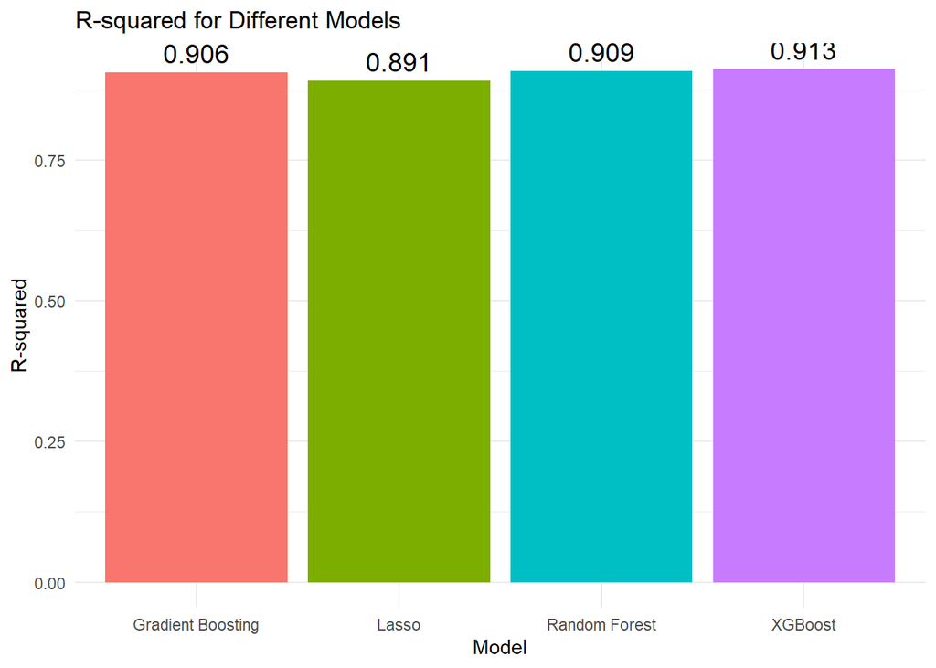

```r
# Calculate R-squared for each model
rsq_lasso <- 1 - sum((y_test - predictions_lasso)^2) / sum((y_test - mean(y_test))^2)
rsq_rf <- 1 - sum((y_test - predictions_rf)^2) / sum((y_test - mean(y_test))^2)
rsq_gboost <- 1 - sum((y_test - predictions_gboost)^2) / sum((y_test - mean(y_test))^2)
rsq_xgb <- 1 - sum((y_test - predictions_xgb)^2) / sum((y_test - mean(y_test))^2)

# Create a data frame for the R-squared values
model_names <- c("Lasso", "Random Forest", "Gradient Boosting", "XGBoost")
rsq_values <- c(rsq_lasso, rsq_rf, rsq_gboost, rsq_xgb)

rsq_df <- data.frame(Model = model_names, R_Squared = rsq_values)

# Plot the R-squared values
library(ggplot2)

ggplot(rsq_df, aes(x = Model, y = R_Squared, fill = Model)) +
  geom_bar(stat = "identity") +
  geom_text(aes(label = round(R_Squared, 3)), vjust = -0.5, size = 5) +
  theme_minimal() +
  labs(title = "R-squared for Different Models", x = "Model", y = "R-squared") +
  theme(legend.position = "none")
```

These R-squared values indicate that all models have strong predictive performance, with R-squared values close to 1, suggesting that they explain a high proportion of the variance in the target variable, SalePrice.

## Evaluation

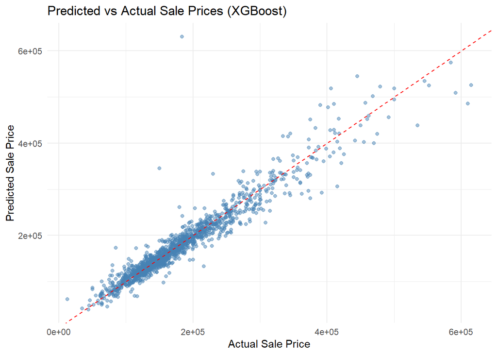

```r
# Plot Predicted vs Actual SalePrice (for XGBoost model)
plot_df <- data.frame(
  Actual = y_test,
  Predicted = predictions_xgb
)

ggplot(plot_df, aes(x = Actual, y = Predicted)) +
  geom_point(alpha = 0.5, color = "steelblue") +
  geom_abline(intercept = 0, slope = 1, color = "red", linetype = "dashed") +
  theme_minimal() +
  labs(title = "Predicted vs Actual Sale Prices (XGBoost)",
       x = "Actual Sale Price",
       y = "Predicted Sale Price")
```

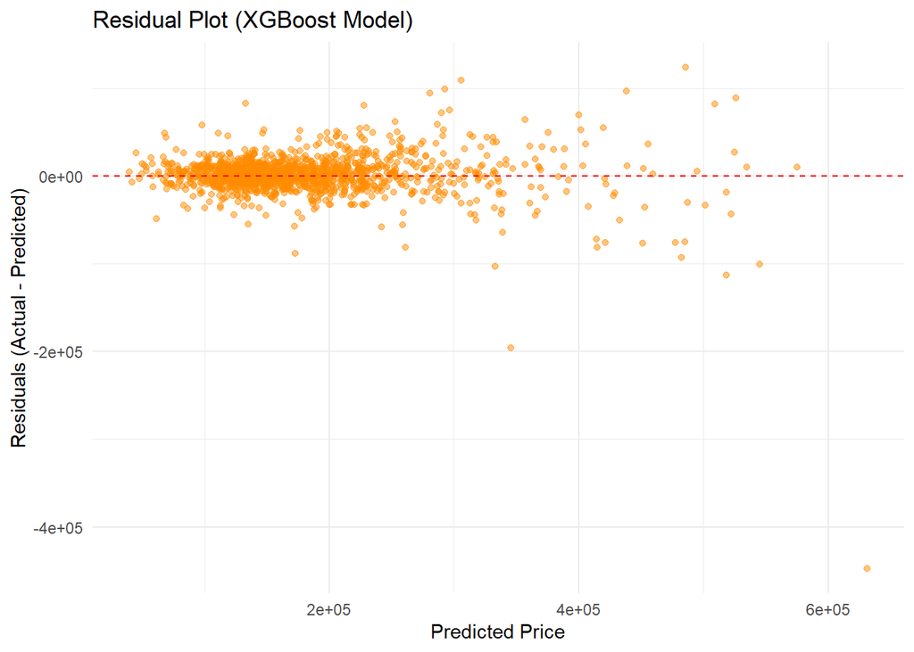

```r
# Plot residuals
plot_df$Residuals <- plot_df$Actual - plot_df$Predicted
ggplot(plot_df, aes(x = Predicted, y = Residuals)) +
  geom_point(alpha = 0.5, color = "darkorange") +
  geom_hline(yintercept = 0, color = "red", linetype = "dashed") +
  theme_minimal() +
  labs(title = "Residual Plot (XGBoost Model)",
       x = "Predicted Price",
       y = "Residuals (Actual - Predicted)")
```

## Important varaible

```r
# Get feature importance from XGBoost
importance_matrix <- xgb.importance(model = xgb_model)
head(importance_matrix, 10)
```

```
##         Feature   Gain   Cover Frequency
##          <char>  <num>   <num>     <num>
##  1:     TotalSF 0.3512 0.06822   0.06536
##  2: OverallQual 0.3223 0.02860   0.02513
##  3:  GarageCars 0.0332 0.00248   0.00314
##  4:   GrLivArea 0.0313 0.04362   0.04724
##  5:   ExterQual 0.0289 0.00245   0.00302
##  6:  BsmtFinSF1 0.0230 0.05047   0.04567
##  7:    BsmtQual 0.0213 0.00511   0.00701
##  8:   YearBuilt 0.0166 0.03243   0.02936
##  9:     LotArea 0.0153 0.05734   0.06355
## 10: TotalBsmtSF 0.0143 0.05659   0.04857
```